# Propensity Score Example

Laha Ale, Robert Gentleman

Updated on : Sun Feb 23 14:40:35 2025

## 1. Goal

The goal of this vignette is to demonstrate the use of propensity score matching using NHANES as an example. We want to look at smoking as the exposure of interest. We will look at individuals over 40 as our cohort of interest We will, at least for V1, ignore the survey weights - although they are important and can be incorporated.

Useful information on propensity score matching can be found in this book chapter by Andrew Gelman and Jennifer Hill (chapter 10), https://sites.stat.columbia.edu/gelman/arm/

We will use data from 2015-2016 and 2017-2018 which cover two NHANES cycles, the data tables we want will have the suffixes `_I` and `_J`.

You will want to use the NHANES in Docker project, here https://github.com/deepayan/nhanes-postgres

And the phonto package which is here: https://github.com/ainilaha/phonto and can be installed using the standard R tools for installing packages from github (if needed, there is a version in the Docker container, but it might not be the most up to date).

## 1. Load libs

```r
library(splines)
library(ggplot2)
library(ggpubr)
library(dplyr)
library(nhanesA)
library(phonto)
library(knitr)
library("MatchIt")
```

## 2. Data and Preprocessiing

#### 2.1) Loading the Demographic, Body Measures, and Cholesterol data into R

The authors state: Participants with cobalt and lipid data were included (n = 6866). Demographic characteristics of the participants, including age, gender, body mass index (BMI), education level, race, family poverty-income ratio and smoking status, were collected. Clinical data, such as blood pressure, total cholesterol (TC), low-density lipoprotein cholesterol (LDL-C), HDL-C, triglycerides (TGs), hypertension, diabetes and history of medication use, including antihypertensive drugs, hypoglycemic drugs, and lipid-lowering drugs, were extracted.

```r
cancerTab=nhanes("MCQ_J")
#MCQ160O  #COPD
#MCQ160B  #Ever told had congestive heart failure
#MCQ203   #Ever been told you have jaundice?
#MCQ220   #Ever told you had cancer or malignancy

##consider getting DIQ_J: Diabetes status. and
##PAQ_J: Physical activity.
## DR1/DR2_J: Dietary intake (sodium, potassium).
```

```r
##get the appropriate table names for the variables we will need
##BP
BPTabs = nhanesSearchVarName("BPQ050A", ystart="2015", ystop="2018")
LDLTabs = nhanesSearchVarName('LBDLDL',ystart="2015", ystop="2018")
##BPQ050A - currently taking meds for hypertension
##BPQ080 - told by Dr. you have high cholesterol
##BPQ100D - now taking meds for high cholesterol
##A1C
A1C = nhanesSearchVarName("LBXGH",ystart="2015", ystop="2018")
##been told by Dr. has diabetes
DrDiab = nhanesSearchVarName("DIQ010",ystart="2015", ystop="2018")
##DIQ050 - taking insulin now
##DIQ070 - taking pills for blood sugar

##HDLTabs
HDLTabs = nhanesSearchVarName("LBDHDD",ystart="2015", ystop="2018")
BMITabs = nhanesSearchVarName("BMXBMI", ystart="2015", ystop="2018")
BMXTabs = nhanesSearchVarName("BMXBMI",ystart="2015", ystop="2018")
DIQTabs = nhanesSearchVarName("DIQ010",ystart="2015", ystop="2018")
COBTabs = nhanesSearchVarName("LBXBCO",ystart="2015", ystop="2018" )
TotChol = nhanesSearchVarName("LBXTC",ystart="2015", ystop="2018" )

##set up the description of the tables, and variables within those tables we
## will use.  Then use the jointQuery function to merge the tables and to merge
##across cycles

cols = list(DEMO_I=c("RIDAGEYR","RIAGENDR","RIDRETH1","DMDEDUC2", "INDFMPIR"),
            DEMO_J=c("RIDAGEYR","RIAGENDR","RIDRETH1","DMDEDUC2", "INDFMPIR"),
            BPQ_I=c('BPQ050A','BPQ020','BPQ080','BPQ100D'),
            BPQ_J=c('BPQ050A','BPQ020','BPQ080','BPQ100D'),
            HDL_I=c("LBDHDD"),HDL_J=c("LBDHDD"),
            GHB_I="LBXGH",GHB_J="LBXGH",
            DIQ_I=c("DIQ010","DIQ050","DIQ070","DIQ160"),
            DIQ_J=c("DIQ010","DIQ050","DIQ070","DIQ160"),
            BMX_I="BMXBMI", BMX_J="BMXBMI",
            TCHOL_I="LBXTC", TCHOL_J="LBXTC",
            SMQ_I=c("SMQ020","SMD030","SMQ040","SMQ050Q", "SMQ050U", "SMD057","SMD650"),             SMQ_J=c("SMQ020","SMD030","SMQ040","SMQ050Q", "SMQ050U", "SMD057","SMD650"),
            BPX_I=c("BPXDI1","BPXDI2","BPXSY1","BPXSY2"),
            BPX_J=c("BPXDI1","BPXDI2","BPXSY1","BPXSY2"),
            TRIGLY_I=c("LBXTR","LBDLDL"), TRIGLY_J=c("LBXTR","LBDLDL"),
            MCQ_I = c("MCQ160O","MCQ160B", "MCQ203", "MCQ220"),
            MCQ_J = c("MCQ160O","MCQ160B", "MCQ203", "MCQ220")
            )
var2Table = cols[c(1,3,5,7,9,11,13,15,17,19,21,23)]
base_df <- jointQuery(cols)


## the authors report only using individuals aged 40 and above, so we will subset to that group

base_df = base_df[base_df$RIDAGEYR>=40,]
dim(base_df)
```

```
#> [1] 7648   37
```

```r
##now we need to fix things up for a small number of individuals where their smoking
## data seem incongrous
badsmIds = c("85753", "98227", "98489", "100515", "95209", "89327", "97353", "97847")

base_df = base_df[!(base_df$SEQN %in% badsmIds),]

##how many of the individuals in our cohort have complete data for all variables?
table(complete.cases(base_df))
```

```
#>
#> FALSE
#>  7640
```

#### Modify the NHANES phenotypes

Now we look at some of the different variables that are going to be used in the analysis. The authors combined the reported ethnicities of Mexican American and Other Hispanic into one group. So we will duplicate that. They also combined the education levels into three groups, those who had no high school record, some high school, through to completion, or some education beyond high school. In the code below we carry out similar transformations of the data.

```r
##Education levels
base_df$DMDEDUC2 = factor(base_df$DMDEDUC2)

levels(base_df$DMDEDUC2) <- c("HS",">HS",NA,"HS","<HS",NA,">HS")
table(base_df$DMDEDUC2)
```

```
#>
#>   HS  >HS  <HS
#> 2640 4025  958
```

```r
##Ethnicity

base_df$RIDRETH1 = factor(base_df$RIDRETH1)
levels(base_df$RIDRETH1) = c("Hispanic/Mexican", "Non-Hispanic Black", "Non-Hispanic White",
                          "Hispanic/Mexican", "Other")

table(base_df$RIDRETH1)
```

```
#>
#>   Hispanic/Mexican Non-Hispanic Black Non-Hispanic White              Other
#>               1973               1712               2705               1250
```

Now, for smoking things are a bit challenging because people with cancer diagnoses probably quit once they got their diagnosis. So we want to try to see how to adjust a historical diagnosis of cancer with some sort of exposure.

```r
##Fixup the smoking variable there are some
##challenges with this so read the documentation in SMQ_J and SMQ_I carefully

##Refused and Don't know into NA
table(base_df$SMQ020, useNA="always")
```

```
#>
#> Don't know         No    Refused        Yes       <NA>
#>          7       4173          1       3459          0
```

```r
base_df$SMQ020 = ifelse(base_df$SMQ020 %in% c("Don't know", "Refused"), NA, base_df$SMQ020)
##for SMQ040 too
table(base_df$SMQ040, useNA="always")
```

```
#>
#>  Every day Not at all  Some days       <NA>
#>       1053       2157        249       4181
```

```r
smokingVar = ifelse(base_df$SMQ020=="No", "Non-smoker",
                    ifelse(base_df$SMQ040=="Not at all", "Ex-smoker",
                    "Smoker"))
table(smokingVar, useNA="always")
```

```
#> smokingVar
#>  Ex-smoker Non-smoker     Smoker       <NA>
#>       2157       4173       1302          8
```

```r
##SMQ050Q is time since quit - but in three different units
##they used 66666 to represent 50 - not at all sure why
##order of operations matters here
base_df$SMQ050U[base_df$SMQ050Q == 66666] = "Years"
base_df$SMQ050Q[base_df$SMQ050Q == 66666] = 50

# time since quitting in years -
tsq = ifelse(base_df$SMQ050U == "Months", base_df$SMQ050Q/12,
             ifelse(base_df$SMQ050U == "Days", base_df$SMQ050Q/365,
                    ifelse(base_df$SMQ050U == "Years", base_df$SMQ050Q, 0)))

##set the NAs to zero, this is mainly the non-smokers but it may also
##affect those that refused for other reasons
#tsq[is.na(base_df$SMQ050Q)] = 0

## years smoking is then their current age - tsq - agetheystarted SMQ030
## check for missing values
sum(base_df$SMD030 > 100, na.rm=T)
```

```
#> [1] 0
```

```r
ageStartSm = ifelse(base_df$SMQ020 == "No", base_df$RIDAGEYR, base_df$SMD030)

sum(is.na(ageStartSm))
```

```
#> [1] 33
```

```r
ageStopped = base_df$RIDAGEYR - tsq

yearsSmoked = ageStopped - ageStartSm
##set these to zero for now
yearsSmoked[is.na(yearsSmoked)] =0

##note this oddity - maybe I have not processed the data
##correctly - or there is some issue with the units for time
## since smoking - eg if the resp. gave something in days or months
## but it was written as years?
which((base_df$RIDAGEYR- yearsSmoked)<10)
```

```
#>  [1] 1919 2383 2458 3284 3713 3781 4174 4493 4738 5439 5559 5709 5884 6383 6692
#> [16] 7050 7352 7495
```

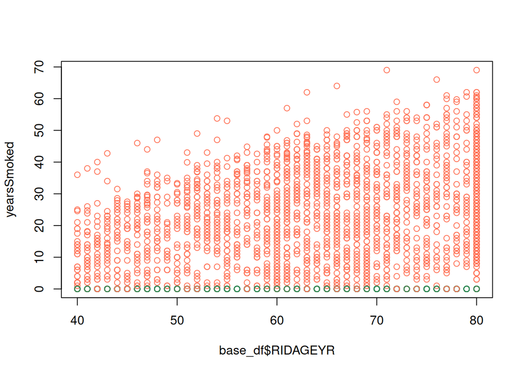

```r
plot(base_df$RIDAGEYR, yearsSmoked, col=ifelse(base_df$SMQ020=="Yes", "coral1", "seagreen"))
```

```r
sum(is.na(base_df$SMD057))
```

```
#> [1] 5504
```

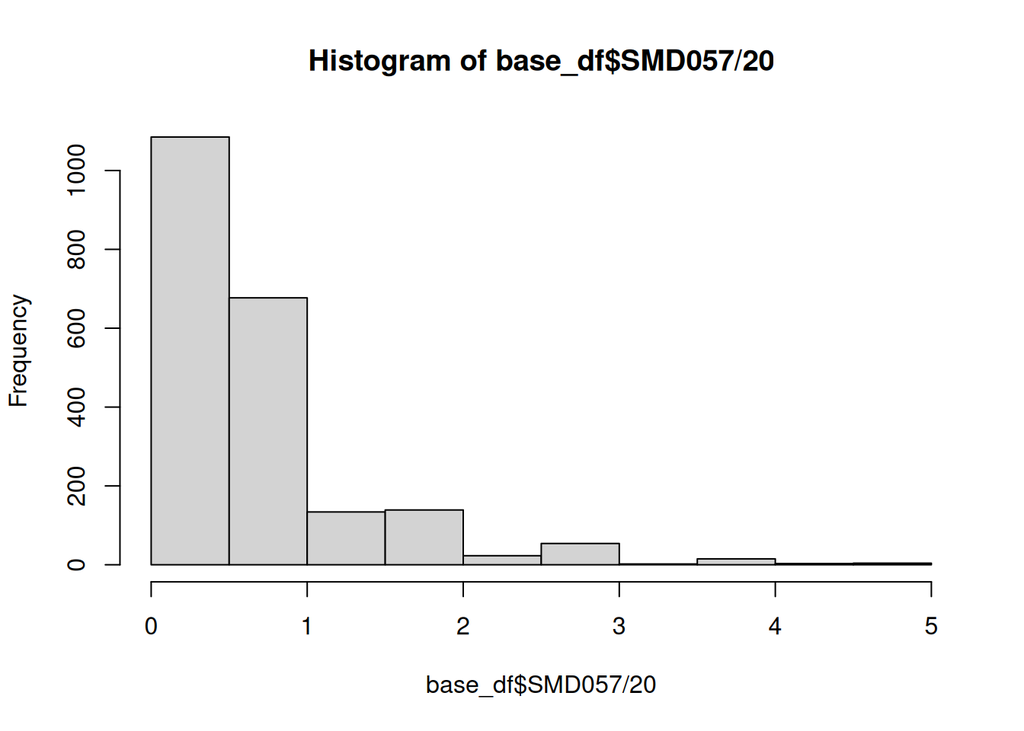

```r
hist(base_df$SMD057/20)
```

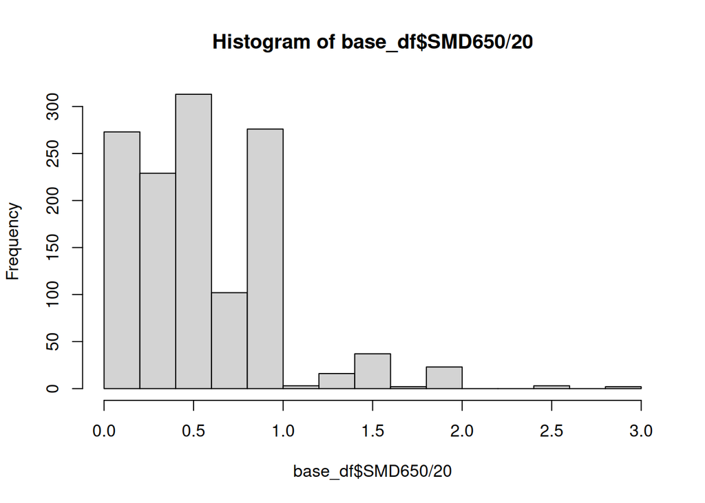

```r
hist(base_df$SMD650/20)
```

```r
##to get pack years we need to get packs/year and
##then multiply by years - both SMD057 and SMD650 are
##in # of cigs so need to divide by 20
## numbers are much larger for SMD057 - which may
## reflect some memory issues, but also those might
##have been the heavier smokers
##NCI says:It is calculated by multiplying the number of packs of cigarettes smoked per day by the number of years the person has smoked.

pksSmoked = ifelse(!is.na(base_df$SMD057), base_df$SMD057/20,
                   ifelse(!is.na(base_df$SMD650), base_df$SMD650/20, 0))

base_df$yearsSmoked = yearsSmoked
base_df$packYears = yearsSmoked * pksSmoked
base_df$smokingVar = smokingVar

##Poverty level - grouped as <1,  could be more granular
## others use <1, 1-4.99 and >=5, but we want binary
  PL = cut(base_df$INDFMPIR, breaks=c(-1,1,6), right=FALSE)
  levels(PL) = c("<=1.0", ">1")
  base_df$PL = PL
```

## Looking at the other features in the data set

FIXME: Deepayan - not sure how we are automating this.

```r
cholMeds = base_df$BPQ100D
table(cholMeds, useNA="always")
```

```
#> cholMeds
#> Don't know         No        Yes       <NA>
#>          7        776       2252       4605
```

```r
cholMeds[base_df$BPQ080=="No"] = "No"
cholMeds[cholMeds=="Don't know"] = NA
cholMeds = factor(cholMeds)
table(cholMeds,useNA="always")
```

```
#> cholMeds
#>   No  Yes <NA>
#> 4764 1971  905
```

```r
base_df$cholMeds=cholMeds

##now fixup the oral meds for diabetes
##not counting insulin right now...might need it
dontskip = base_df$DIQ010 == "Yes" | base_df$DIQ010 == "Borderline" | base_df$DIQ160 == "Yes"
hypoglycemicMeds = base_df$DIQ070
hypoglycemicMeds[!dontskip] = "No"
hypoglycemicMeds = factor(hypoglycemicMeds,levels=c("Yes", "No", "Don't know","Refused"), labels=c("Yes", "No",NA,NA))
table(hypoglycemicMeds,useNA="always")
```

```
#> hypoglycemicMeds
#>  Yes   No <NA>
#> 1296 6339    5
```

```r
base_df$hypoglycemicMeds = hypoglycemicMeds
```

In the next code chunk we load the glucose data.

```r
##fasting glucose
Fastgluc = nhanesSearchVarName("LBXGLU", ystart="2015", ystop="2018")
glucTab = unionQuery(list(GLU_I="LBXGLU", GLU_J="LBXGLU"))
base_df = merge(base_df, glucTab, all.x=TRUE)
```

#### Blood Pressure Data

Both systolic (BPXS) and diastolic (BPXD) measurements were taken twice, on two separate occassions. The authors of the Cobalt paper do not specify how they dealt this, did they use the first, the second, an average of the two? How did they deal with individuals that did not show up for their second measurement? We will use the average of these two measurements for individuals with two measurements, and in the case where only one measurement is available we will use it. The authors of the Cobalt paper don’t specify which values they used, so this is one of the places where our analysis may differ from theirs.

```r
##fixup the blood pressure data - using averages
# Average the the first and second reads
# taking some care to keep one measurement if the other is missing
base_df$DIASTOLIC <- rowMeans(base_df[, c("BPXDI1", "BPXDI2")], na.rm=TRUE)
base_df$DIASTOLIC[is.na(base_df$BPXDI1) & is.na(base_df$BPXDI2)] = NA
base_df$SYSTOLIC <- rowMeans(base_df[, c("BPXSY1", "BPXSY2")], na.rm=TRUE)
base_df$SYSTOLIC[is.na(base_df$BPXSY1) & is.na(base_df$BPXSY2)] = NA
```

In our analysis we can then look at the average of the measurements across the two different time points as a way to estimate the actual blood pressure for each participant.

In the code below we want to adjust the reported answers for the question about the use of hypertensive medicines. Because of the way the survey was carried out, individuals who responded “No” when asked if they had ever been told they had high blood pressure were never asked if they were taking medication for high blood pressure. It seems reasonable to assume that they would have said “No” had they been asked and so we make that adjustment. Otherwise such individuals will have a missing value for that variable and will be removed during many of the modeling steps we report on below. Different users might choose to address this in different ways. We want to maximize the number of cases and feel that this is a reasonable choice.

```r
##
## fixup the data for a skipped question
hypertensiveMeds = base_df$BPQ050A
hypertensiveMeds[base_df$BPQ020=="No"] = "No"
hypertensiveMeds[base_df$BPQ040A=="No"] = "No"

base_df$BPQ050A = hypertensiveMeds
```

## 2.4 Definitions

https://wwwn.cdc.gov/nchs/nhanes/2011-2012/BPQ_G.htm

```r
# "Hypertension was defined as systolic blood pressure (SBP) ≥140 mm Hg, diastolic blood pressure ≥90mm Hg, or the use of antihypertensive medication. "
base_df$hypertension <- base_df$DIASTOLIC >= 90 | base_df$SYSTOLIC >= 140 |  base_df$BPQ050A=="Yes"
table(base_df$hypertension)
```

```
#>
#> FALSE  TRUE
#>  3038  4061
```

```r
#barplot(table(base_df$hypertension))
```

```r
base_df$diabetes = base_df$DIQ010 == "Yes" | base_df$LBXGLU > 110 | base_df$LBXGH > 6.5
#barplot(table(base_df$diabetes))

base_df$HighLDL = base_df$LBDLDL > 130
#barplot(table(base_df$HighLDL))

base_df$LowHDL = (base_df$RIAGENDR=="Male" & base_df$LBDHDD < 40) |    (base_df$RIAGENDR=="Female" & base_df$LBDHDD < 50)
#barplot(table(base_df$LowHDL))
```

Now lets define the elevated total cholesterol variable.

```r
elevatedTC = base_df$LBXTC>200
base_df$elevatedTC = elevatedTC
```

## 3. Propensity Models

Here we will start to think of what the model should look like. We want to perform a logistic regression on some known risk factors, where the outcome is our exposure of interest. So we will look at smoking (or some variant).

We will study its risk for cancer outomes so we want to make sure we adjust for a number of cancer risk factors.

What will we look for: Age: cancer risk increases with age, in a non-linear way (splines). Sex: Race/Ethnicity: Socioeconomic Status: Obesity (BMI, Waist Circumference):

We need a little more fixing up variables to get all missing values in place.

```r
##we might want to just get to complete cases at some point
base_df$MCQ220 = ifelse(base_df$MCQ220 == "Don't know", NA, base_df$MCQ220)

##notice that current smokers seem to have a cancer rate similar to non-smokers
## ex-smokers are much more likely to have been told they have cancer
t1 = table(base_df$smokingVar, base_df$MCQ220)
prop.table(t1, margin = 1)
```

```
#>
#>                     No       Yes
#>   Ex-smoker  0.8051948 0.1948052
#>   Non-smoker 0.8806042 0.1193958
#>   Smoker     0.8784615 0.1215385
```

Now a couple of plots to reveal a little of what is going on. So pack years seems to be much higher for ex-smokers than for current smokers. This could be true (or maybe an error in the analysis above). Recall that for NHANES we are really getting historical data on disease, which for cancer means that the respondent survived and/or was well enough to participate in the study. That would be different than studying existing cancer cases. And it seems plausible that anyone with a cancer diagnosis would stop smoking - and become an ex-smoker. And it also seems plausible that heavy smokers would be more likely to get cancer - and hence to become ex-smokers….

In any event it seems that the smoking variable does not work that well for predicting self-reported cancer and so we probably want to use pack years as our exposure in the propensity score modeling below.

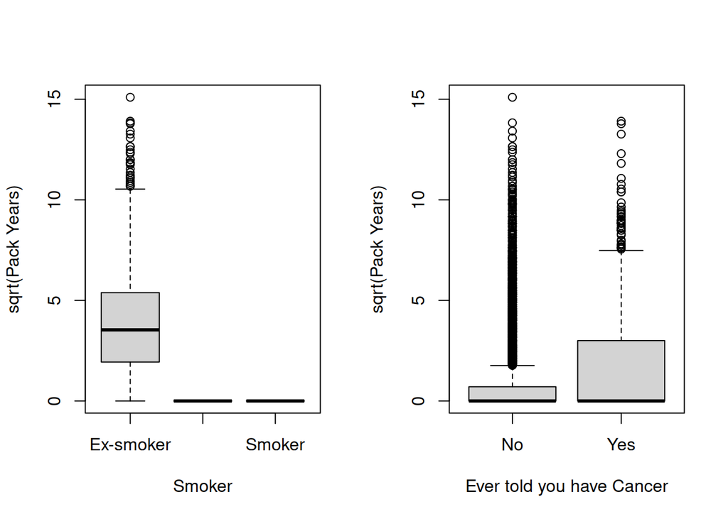

```r
par(mfrow=c(1,2))
boxplot(sqrt(base_df$packYears) ~ base_df$smokingVar, xlab="Smoker",
        ylab="sqrt(Pack Years)")

boxplot(sqrt(base_df$packYears) ~ base_df$MCQ220, xlab="Ever told you have Cancer",
        ylab="sqrt(Pack Years)")
```

```r
chisq.test(table(base_df$smokingVar, base_df$MCQ220))
```

```
#>
#>  Pearson's Chi-squared test
#>
#> data:  table(base_df$smokingVar, base_df$MCQ220)
#> X-squared = 71.638, df = 2, p-value = 2.78e-16
```

```r
base_df$anySmoke = ifelse(base_df$smokingVar == "Non-smoker", 0, 1)
base_df$obese = ifelse(base_df$BMXBMI >= 30, TRUE, FALSE)
```

Now let’s get complete cases and examine the fit of our logistic regression model. It seems like there are good reasons to include interactions in the propensity score matching algorithms.  
I don’t have a good sense of whether that is more true for discrete variables than it is for linear variables, but I think it might be.

```r
##let's get complete cases
subdf = base_df[,c("anySmoke", "packYears", "RIDAGEYR", "RIAGENDR", "obese", "RIDRETH1", "PL", "MCQ220")]

baseCC = subdf[complete.cases(subdf),]
baseCC$cancer = ifelse(baseCC$MCQ220=="Yes", 1, 0)

##first - check that packYears is predictive of a reported cancer
##probably we want a spline for packYears, but since there are so
##many zeros we need to hand set the knots
glm0 = glm(cancer ~ ns(packYears, knots=c(1,11,30,50)), data = baseCC, family="binomial")
glm0a = glm(cancer ~ sqrt(packYears),  data=baseCC, family="binomial" )
glm0b = glm(cancer ~ packYears, data=baseCC, family="binomial" )
summary(glm0)
```

```
#>
#> Call:
#> glm(formula = cancer ~ ns(packYears, knots = c(1, 11, 30, 50)),
#>     family = "binomial", data = baseCC)
#>
#> Coefficients:
#>                                          Estimate Std. Error z value Pr(>|z|)
#> (Intercept)                              -1.99045    0.04518 -44.057  < 2e-16
#> ns(packYears, knots = c(1, 11, 30, 50))1  0.29568    0.27027   1.094  0.27396
#> ns(packYears, knots = c(1, 11, 30, 50))2  0.98419    0.21974   4.479  7.5e-06
#> ns(packYears, knots = c(1, 11, 30, 50))3  0.60069    0.49257   1.220  0.22265
#> ns(packYears, knots = c(1, 11, 30, 50))4  1.32615    0.43583   3.043  0.00234
#> ns(packYears, knots = c(1, 11, 30, 50))5  0.67673    0.85864   0.788  0.43061
#>
#> (Intercept)                              ***
#> ns(packYears, knots = c(1, 11, 30, 50))1
#> ns(packYears, knots = c(1, 11, 30, 50))2 ***
#> ns(packYears, knots = c(1, 11, 30, 50))3
#> ns(packYears, knots = c(1, 11, 30, 50))4 **
#> ns(packYears, knots = c(1, 11, 30, 50))5
#> ---
#> Signif. codes:  0 '***' 0.001 '**' 0.01 '*' 0.05 '.' 0.1 ' ' 1
#>
#> (Dispersion parameter for binomial family taken to be 1)
#>
#>     Null deviance: 5095.6  on 6264  degrees of freedom
#> Residual deviance: 5023.2  on 6259  degrees of freedom
#> AIC: 5035.2
#>
#> Number of Fisher Scoring iterations: 4
```

```r
#next fit the model we are most interested in, on the entire dataset
#so we can compare with the fit after doing propensity score matching
# since packYears and age are going to be highly correlated, we won't include
#an interaction in the model between the two
glm1 = glm(cancer ~ ns(RIDAGEYR, df=7) +
             sqrt(packYears) * (obese + RIAGENDR + PL + RIDRETH1) +
             RIAGENDR:PL + RIDRETH1:RIAGENDR:RIDRETH1 + obese:PL + obese:RIDRETH1
         + obese:RIAGENDR ,  data=baseCC, family="binomial")

summary(glm1)
```

```
#>
#> Call:
#> glm(formula = cancer ~ ns(RIDAGEYR, df = 7) + sqrt(packYears) *
#>     (obese + RIAGENDR + PL + RIDRETH1) + RIAGENDR:PL + RIDRETH1:RIAGENDR:RIDRETH1 +
#>     obese:PL + obese:RIDRETH1 + obese:RIAGENDR, family = "binomial",
#>     data = baseCC)
#>
#> Coefficients:
#>                                            Estimate Std. Error z value Pr(>|z|)
#> (Intercept)                                -4.06359    0.43055  -9.438  < 2e-16
#> ns(RIDAGEYR, df = 7)1                       1.21036    0.43021   2.813  0.00490
#> ns(RIDAGEYR, df = 7)2                       1.50250    0.49560   3.032  0.00243
#> ns(RIDAGEYR, df = 7)3                       1.79496    0.42617   4.212 2.53e-05
#> ns(RIDAGEYR, df = 7)4                       2.35312    0.45026   5.226 1.73e-07
#> ns(RIDAGEYR, df = 7)5                       2.54013    0.32125   7.907 2.63e-15
#> ns(RIDAGEYR, df = 7)6                       3.72967    0.89074   4.187 2.82e-05
#> ns(RIDAGEYR, df = 7)7                       2.35987    0.20422  11.555  < 2e-16
#> sqrt(packYears)                             0.10147    0.05795   1.751  0.07994
#> obeseTRUE                                   0.13094    0.24582   0.533  0.59427
#> RIAGENDRMale                               -0.78847    0.26811  -2.941  0.00327
#> PL>1                                       -0.13570    0.17969  -0.755  0.45012
#> RIDRETH1Non-Hispanic Black                  0.03161    0.23683   0.133  0.89382
#> RIDRETH1Non-Hispanic White                  0.89241    0.18571   4.805 1.55e-06
#> RIDRETH1Other                              -0.02333    0.23929  -0.098  0.92233
#> sqrt(packYears):obeseTRUE                  -0.01079    0.03060  -0.353  0.72440
#> sqrt(packYears):RIAGENDRMale               -0.04716    0.03211  -1.469  0.14192
#> sqrt(packYears):PL>1                        0.01425    0.04350   0.328  0.74324
#> sqrt(packYears):RIDRETH1Non-Hispanic Black -0.03477    0.06160  -0.564  0.57246
#> sqrt(packYears):RIDRETH1Non-Hispanic White -0.07317    0.04796  -1.526  0.12705
#> sqrt(packYears):RIDRETH1Other               0.03138    0.07127   0.440  0.65970
#> RIAGENDRMale:PL>1                           0.38741    0.22158   1.748  0.08039
#> RIAGENDRMale:RIDRETH1Non-Hispanic Black     0.69805    0.27580   2.531  0.01137
#> RIAGENDRMale:RIDRETH1Non-Hispanic White     0.49489    0.22748   2.175  0.02959
#> RIAGENDRMale:RIDRETH1Other                 -0.16264    0.32985  -0.493  0.62196
#> obeseTRUE:PL>1                              0.01884    0.21904   0.086  0.93144
#> obeseTRUE:RIDRETH1Non-Hispanic Black       -0.54566    0.26956  -2.024  0.04295
#> obeseTRUE:RIDRETH1Non-Hispanic White       -0.30374    0.21873  -1.389  0.16494
#> obeseTRUE:RIDRETH1Other                     0.21557    0.33420   0.645  0.51891
#> obeseTRUE:RIAGENDRMale                      0.17029    0.16506   1.032  0.30221
#>
```

[output cut: 25 more lines]

```
#> obeseTRUE:PL>1
#> obeseTRUE:RIDRETH1Non-Hispanic Black       *
#> obeseTRUE:RIDRETH1Non-Hispanic White
#> obeseTRUE:RIDRETH1Other
#> obeseTRUE:RIAGENDRMale
#> ---
#> Signif. codes:  0 '***' 0.001 '**' 0.01 '*' 0.05 '.' 0.1 ' ' 1
#>
#> (Dispersion parameter for binomial family taken to be 1)
#>
#>     Null deviance: 5095.6  on 6264  degrees of freedom
#> Residual deviance: 4410.1  on 6235  degrees of freedom
#> AIC: 4470.1
#>
#> Number of Fisher Scoring iterations: 6
```

```r
lm1 = lm(sqrt(packYears) ~ ns(RIDAGEYR, df=7) + obese + RIAGENDR+PL+RIDRETH1
           +RIAGENDR:PL+ RIDRETH1:PL + RIAGENDR:RIDRETH1 + obese:PL + obese:RIDRETH1
         + obese:RIAGENDR,  data=baseCC)

summary(lm1)
```

```
#>
#> Call:
#> lm(formula = sqrt(packYears) ~ ns(RIDAGEYR, df = 7) + obese +
#>     RIAGENDR + PL + RIDRETH1 + RIAGENDR:PL + RIDRETH1:PL + RIAGENDR:RIDRETH1 +
#>     obese:PL + obese:RIDRETH1 + obese:RIAGENDR, data = baseCC)
#>
#> Residuals:
#>     Min      1Q  Median      3Q     Max
#> -3.2479 -1.2485 -0.5584  0.2527 11.4229
#>
#> Coefficients:
#>                                          Estimate Std. Error t value Pr(>|t|)
#> (Intercept)                             -0.228208   0.184993  -1.234 0.217398
#> ns(RIDAGEYR, df = 7)1                    0.245377   0.177882   1.379 0.167810
#> ns(RIDAGEYR, df = 7)2                    0.280272   0.210212   1.333 0.182488
#> ns(RIDAGEYR, df = 7)3                    0.844490   0.181708   4.648 3.43e-06
#> ns(RIDAGEYR, df = 7)4                    1.057559   0.213444   4.955 7.43e-07
#> ns(RIDAGEYR, df = 7)5                    1.328770   0.187415   7.090 1.49e-12
#> ns(RIDAGEYR, df = 7)6                    1.349983   0.317958   4.246 2.21e-05
#> ns(RIDAGEYR, df = 7)7                    1.465716   0.114358  12.817  < 2e-16
#> obeseTRUE                                0.207295   0.151798   1.366 0.172113
#> RIAGENDRMale                             0.659667   0.153340   4.302 1.72e-05
#> PL>1                                     0.178793   0.151733   1.178 0.238707
#> RIDRETH1Non-Hispanic Black               0.185570   0.190147   0.976 0.329139
#> RIDRETH1Non-Hispanic White               0.293325   0.185199   1.584 0.113282
#> RIDRETH1Other                           -0.006449   0.215291  -0.030 0.976102
#> RIAGENDRMale:PL>1                        0.148456   0.137210   1.082 0.279310
#> PL>1:RIDRETH1Non-Hispanic Black         -0.026667   0.178573  -0.149 0.881295
#> PL>1:RIDRETH1Non-Hispanic White         -0.127113   0.176864  -0.719 0.472349
#> PL>1:RIDRETH1Other                      -0.247468   0.211295  -1.171 0.241565
#> RIAGENDRMale:RIDRETH1Non-Hispanic Black -0.588383   0.155737  -3.778 0.000160
#> RIAGENDRMale:RIDRETH1Non-Hispanic White  0.176938   0.138555   1.277 0.201642
#> RIAGENDRMale:RIDRETH1Other              -0.059046   0.170987  -0.345 0.729861
#> obeseTRUE:PL>1                          -0.278790   0.139498  -1.999 0.045704
#> obeseTRUE:RIDRETH1Non-Hispanic Black     0.139694   0.155563   0.898 0.369224
#> obeseTRUE:RIDRETH1Non-Hispanic White     0.526743   0.139101   3.787 0.000154
#> obeseTRUE:RIDRETH1Other                  0.579064   0.192944   3.001 0.002700
#> obeseTRUE:RIAGENDRMale                   0.245428   0.109347   2.244 0.024836
#>
#> (Intercept)
```

[output cut: 16 more lines]

```
#> PL>1:RIDRETH1Other
#> RIAGENDRMale:RIDRETH1Non-Hispanic Black ***
#> RIAGENDRMale:RIDRETH1Non-Hispanic White
#> RIAGENDRMale:RIDRETH1Other
#> obeseTRUE:PL>1                          *
#> obeseTRUE:RIDRETH1Non-Hispanic Black
#> obeseTRUE:RIDRETH1Non-Hispanic White    ***
#> obeseTRUE:RIDRETH1Other                 **
#> obeseTRUE:RIAGENDRMale                  *
#> ---
#> Signif. codes:  0 '***' 0.001 '**' 0.01 '*' 0.05 '.' 0.1 ' ' 1
#>
#> Residual standard error: 2.074 on 6239 degrees of freedom
#> Multiple R-squared:  0.1289, Adjusted R-squared:  0.1254
#> F-statistic: 36.92 on 25 and 6239 DF,  p-value: < 2.2e-16
```

Now examine the propensity matching.

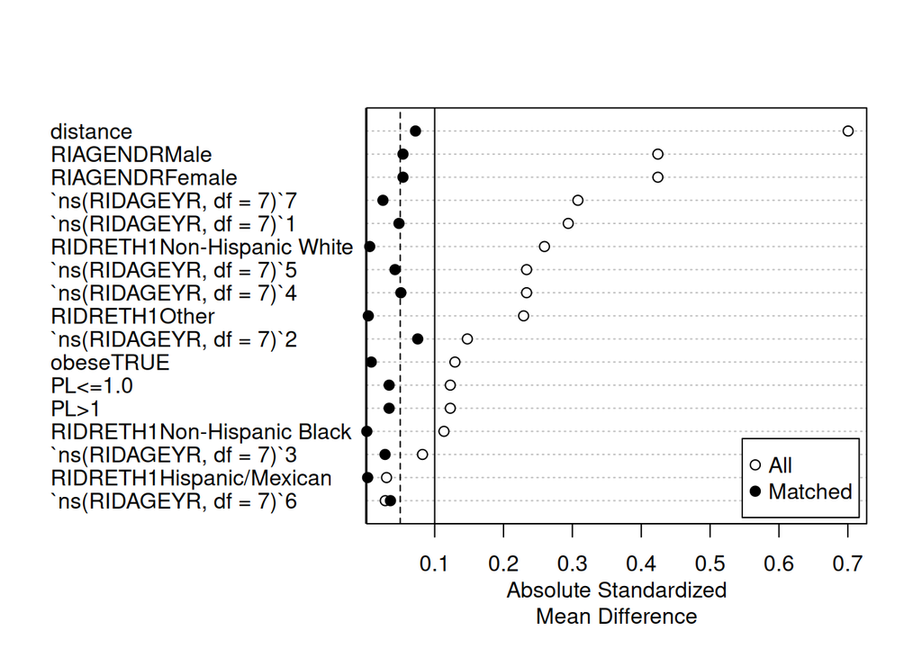

```r
m1 = lm(sqrt(packYears) ~ ns(RIDAGEYR, df=7) + obese + RIAGENDR+PL+RIDRETH1
           +RIAGENDR:PL+RIDRETH1:RIAGENDR:RIDRETH1 + obese:PL + obese:RIDRETH1
         + obese:RIAGENDR,  data=baseCC)

py0 = baseCC$packYears > 0

m.out <- matchit( py0 ~ ns(RIDAGEYR, df=7) + obese + RIAGENDR+PL+RIDRETH1
           +RIAGENDR:PL+ RIDRETH1:PL + RIAGENDR:RIDRETH1 + obese:PL + obese:RIDRETH1
         + obese:RIAGENDR, data=baseCC, replace = FALSE, ratio=1)

m.sum = summary(m.out)
plot(m.sum, var.order = "unmatched")
```

FIXME: produce the per variable density and bar plots

And now compute the different effects on our outcome of interest.

```r
md <- match_data(m.out)

fit1 <- glm( cancer ~ ns(RIDAGEYR, df=7) +
             sqrt(packYears) * (obese + RIAGENDR + PL + RIDRETH1) +
             RIAGENDR:PL + RIDRETH1:RIAGENDR:RIDRETH1 + obese:PL + obese:RIDRETH1
         + obese:RIAGENDR,
           data = md,
           weights = weights, family="binomial")
summary(fit1)
```

```
#>
#> Call:
#> glm(formula = cancer ~ ns(RIDAGEYR, df = 7) + sqrt(packYears) *
#>     (obese + RIAGENDR + PL + RIDRETH1) + RIAGENDR:PL + RIDRETH1:RIAGENDR:RIDRETH1 +
#>     obese:PL + obese:RIDRETH1 + obese:RIAGENDR, family = "binomial",
#>     data = md, weights = weights)
#>
#> Coefficients:
#>                                            Estimate Std. Error z value Pr(>|z|)
#> (Intercept)                                -3.78758    0.57359  -6.603 4.02e-11
#> ns(RIDAGEYR, df = 7)1                       0.88112    0.49995   1.762 0.077998
#> ns(RIDAGEYR, df = 7)2                       1.65573    0.55806   2.967 0.003008
#> ns(RIDAGEYR, df = 7)3                       1.85367    0.50871   3.644 0.000269
#> ns(RIDAGEYR, df = 7)4                       2.29832    0.57317   4.010 6.08e-05
#> ns(RIDAGEYR, df = 7)5                       2.71956    0.49736   5.468 4.55e-08
#> ns(RIDAGEYR, df = 7)6                       3.49848    1.04696   3.342 0.000833
#> ns(RIDAGEYR, df = 7)7                       2.13115    0.28545   7.466 8.27e-14
#> sqrt(packYears)                             0.10778    0.06449   1.671 0.094664
#> obeseTRUE                                   0.15227    0.34681   0.439 0.660624
#> RIAGENDRMale                               -0.69244    0.35578  -1.946 0.051626
#> PL>1                                       -0.37747    0.29805  -1.266 0.205351
#> RIDRETH1Non-Hispanic Black                  0.04388    0.36136   0.121 0.903339
#> RIDRETH1Non-Hispanic White                  1.04804    0.28540   3.672 0.000240
#> RIDRETH1Other                              -0.14103    0.45886  -0.307 0.758586
#> sqrt(packYears):obeseTRUE                  -0.01842    0.03282  -0.561 0.574648
#> sqrt(packYears):RIAGENDRMale               -0.07429    0.03554  -2.090 0.036606
#> sqrt(packYears):PL>1                        0.03620    0.04898   0.739 0.459914
#> sqrt(packYears):RIDRETH1Non-Hispanic Black -0.05224    0.06844  -0.763 0.445256
#> sqrt(packYears):RIDRETH1Non-Hispanic White -0.08801    0.05206  -1.691 0.090908
#> sqrt(packYears):RIDRETH1Other               0.04370    0.08178   0.534 0.593074
#> RIAGENDRMale:PL>1                           0.46022    0.29030   1.585 0.112894
#> RIAGENDRMale:RIDRETH1Non-Hispanic Black     0.81303    0.35177   2.311 0.020818
#> RIAGENDRMale:RIDRETH1Non-Hispanic White     0.44990    0.28093   1.601 0.109276
#> RIAGENDRMale:RIDRETH1Other                 -0.18734    0.45939  -0.408 0.683423
#> obeseTRUE:PL>1                              0.13659    0.28875   0.473 0.636182
#> obeseTRUE:RIDRETH1Non-Hispanic Black       -0.57735    0.34211  -1.688 0.091484
#> obeseTRUE:RIDRETH1Non-Hispanic White       -0.43130    0.27304  -1.580 0.114188
#> obeseTRUE:RIDRETH1Other                     0.36029    0.45500   0.792 0.428459
#> obeseTRUE:RIAGENDRMale                      0.19849    0.19696   1.008 0.313584
#>
```

[output cut: 25 more lines]

```
#> obeseTRUE:PL>1
#> obeseTRUE:RIDRETH1Non-Hispanic Black       .
#> obeseTRUE:RIDRETH1Non-Hispanic White
#> obeseTRUE:RIDRETH1Other
#> obeseTRUE:RIAGENDRMale
#> ---
#> Signif. codes:  0 '***' 0.001 '**' 0.01 '*' 0.05 '.' 0.1 ' ' 1
#>
#> (Dispersion parameter for binomial family taken to be 1)
#>
#>     Null deviance: 3337.7  on 3541  degrees of freedom
#> Residual deviance: 2887.5  on 3512  degrees of freedom
#> AIC: 2947.5
#>
#> Number of Fisher Scoring iterations: 5
```

[output not shown]